# VPT with Robots

Response-Time (RT) Analysis: Full model

Joel Currie[^1], Katrina Louise McDonough[^2], Agnieszka Wykowska[^3], Maria Elena Giannaccini[^4], Patric Bach[^5]

2024-11-10

# Full Model:

## Effects of Interest:

### Self Theta:

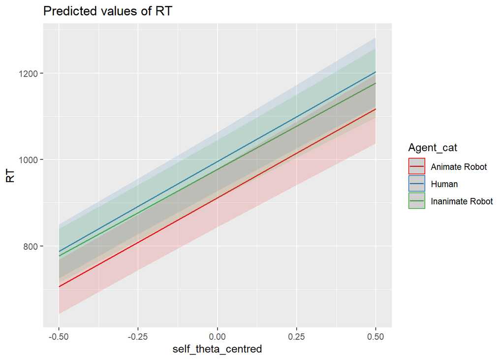

As can be seen above, RTs show the expected linear increase as the disparity between self-perspective and stimulus orientation increases ($E = 412.1, CI = [364.3 - 459.9], p < .001$).

### Other Theta:

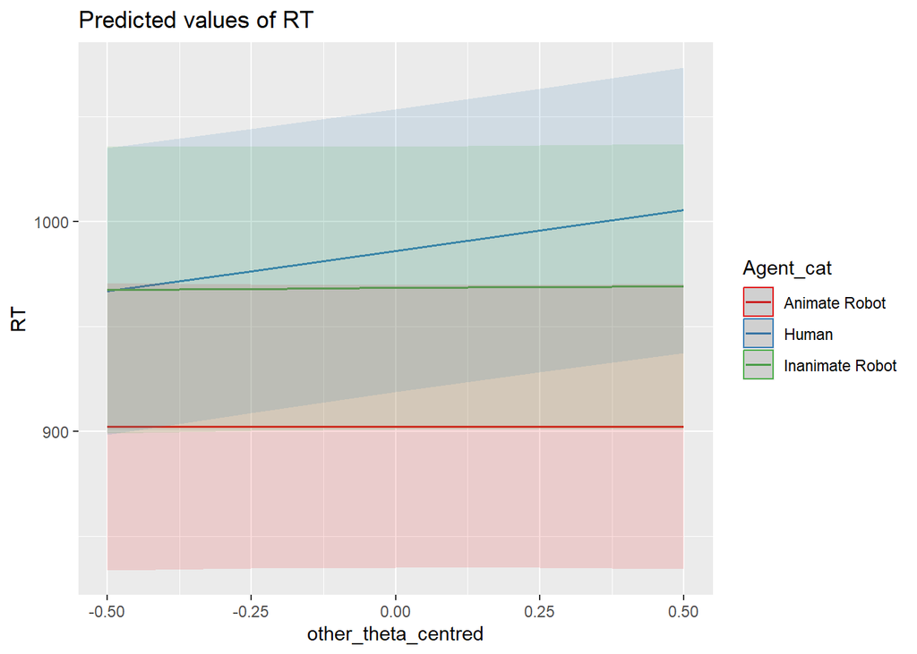

Our full-model failed to identify the main effect of Other-Perspective ($E = -0.2, CI = [-21.4 - 21.0], p = .986$), however detected an interaction between Other-Perspective, and the Human agent category ($E = 39.5, CI = [9.3 - 69.8], p = .010$) signalling that the expected VPT effect was only present in the group where participants were paired with other human participants.

Though visually, there appears to be a systematic difference in RTs between the Animate Robot group and the Human/Inanimate Robot, this is not statistically significant.

## Other Fixed effects and Interactions:

### Exposure:

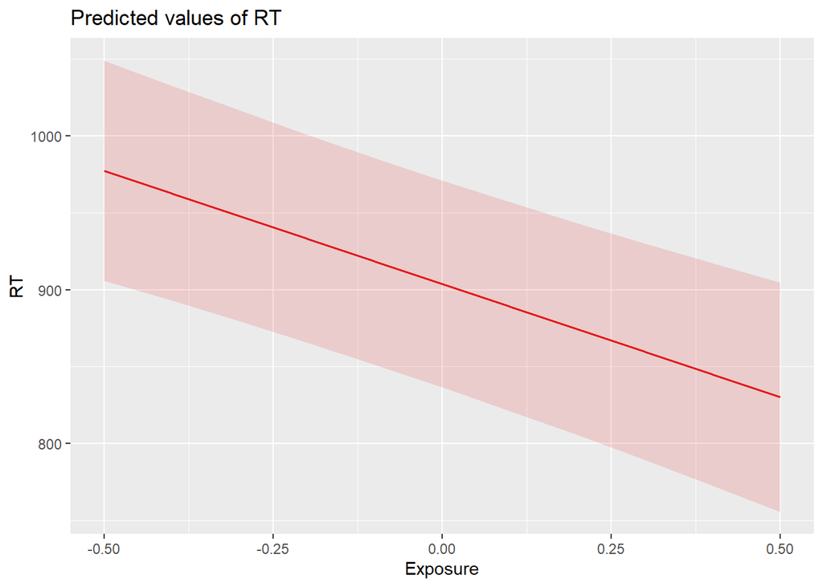

Generally participants RTs got faster over the course of the experiment, as participants were exposed to more trials they became better at the task ($E = -147.5, CI = [-204.0 - -91.0], p < .001$).

### Agent * Exposure* Other_theta:

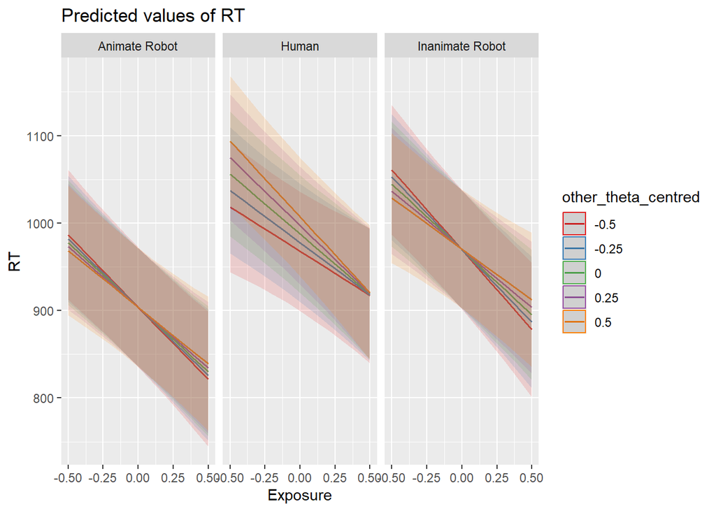

We found a small interaction in the between the Human group, other theta and Exposure ($E = -107.3, CI = [-200.5 - -14.1], p = .024$). This interaction *could* imply that as the experiment progresses participants rely less on their partners perspective, and the VPT effect appears to get weaker.

## Model Construciton:

```r
lmer(RT ~ self_theta_centred * Agent_cat * Exposure + other_theta_centred * Agent_cat * Exposure +
                              (1 + Exposure + self_theta_centred + other_theta_centred|subject)
                            ,data=filter(data, correct == 1), control = lmerControl(optimizer = "bobyqa"))
```

## Output of model:

|  | RT |  |  |
| --- | --- | --- | --- |
| Predictors | Estimates | CI | p |
| (Intercept) | 913.02 | 845.35 – 980.70 | **<0.001** |
| self theta centred | 412.13 | 364.34 – 459.92 | **<0.001** |
| Agent cat [Human] | 83.68 | -12.04 – 179.40 | 0.087 |
| Agent cat [Inanimate Robot] | 65.71 | -30.00 – 161.43 | 0.178 |
| Exposure | -147.52 | -204.04 – -91.01 | **<0.001** |
| other theta centred | -0.19 | -21.39 – 21.01 | 0.986 |
| self theta centred × Agent cat [Human] | 3.41 | -64.36 – 71.18 | 0.921 |
| self theta centred × Agent cat [Inanimate Robot] | -11.21 | -78.88 – 56.46 | 0.745 |
| self theta centred × Exposure | -16.21 | -84.41 – 51.99 | 0.641 |
| Agent cat [Human] × Exposure | 11.22 | -68.79 – 91.24 | 0.783 |
| Agent cat [Inanimate Robot] × Exposure | -3.24 | -83.18 – 76.71 | 0.937 |
| Agent cat [Human] × other theta centred | 39.52 | 9.28 – 69.76 | **0.010** |
| Agent cat [Inanimate Robot] × other theta centred | 1.12 | -29.03 – 31.27 | 0.942 |
| Exposure × other theta centred | 35.20 | -30.13 – 100.53 | 0.291 |
| (self theta centred × Agent cat [Human]) × Exposure | 60.73 | -36.28 – 157.73 | 0.220 |
| (self theta centred × Agent cat [Inanimate Robot]) × Exposure | -33.07 | -129.67 – 63.54 | 0.502 |
| (Agent cat [Human] × Exposure) × other theta centred | -107.30 | -200.54 – -14.07 | **0.024** |
| (Agent cat [Inanimate Robot] × Exposure) × other theta centred | 30.96 | -61.63 – 123.55 | 0.512 |
| Random Effects |  |  |  |
| σ<sup>2</sup> | 62612.43 |  |  |
| τ<sub>00</sub> <sub>subject</sub> | 35490.79 |  |  |
| τ<sub>11</sub> <sub>subject.Exposure</sub> | 21648.86 |  |  |
| τ<sub>11</sub> <sub>subject.self_theta_centred</sub> | 14839.98 |  |  |
| τ<sub>11</sub> <sub>subject.other_theta_centred</sub> | 727.70 |  |  |
| ρ<sub>01</sub> | 0.06 |  |  |
|  | 0.42 |  |  |
|  | -0.03 |  |  |
| ICC | 0.38 |  |  |
| N <sub>subject</sub> | 90 |  |  |
| Observations | 20624 |  |  |
| Marginal R<sup>2</sup> / Conditional R<sup>2</sup> | 0.151 / 0.474 |  |  |

[^1]: University of Aberdeen, j.currie.22@abdn.ac.uk
[^2]: University of East Anglia
[^3]: Istituto Italiano di Tecnologia
[^4]: University of Aberdeen
[^5]: University of Aberdeen